# Predictions for United States Presidential Elections 2016

Harshala Rajesh  
Aug 2016

## Overview

- Project Description
- Dataset
- Exploratory Analysis
- Model
- Results and Conclusions

## Project Description

United States of America being one of the Superpowers, the leader of the country will have a significant influence not just for the country but the entire world. The President of the United States is considered one of the world's most powerful people, leading the world's only contemporary superpower. The role includes being the commander-in-chief of the world's most expensive military with the largest nuclear arsenal and leading the nation with the largest economy by real and nominal GDP. The office of the president holds significant hard and soft power both in the United States and abroad.

The President is elected by Electoral College to a four-year term. Current President Barack Obama will be ending his second four-year term and The United States Presidential Election is scheduled for Tuesday, November 8, 2016. The series of presidential primary elections and caucuses took place between February 1 and June 14, 2016.

Former Secretary of State and New York Senator Hillary Clinton is the Democratic Party's presidential nominee. Businessman and reality television personality Donald Trump is the Republican Party's presidential nominee. Hillary Clinton, if elected will be the first woman to take the Office of the President in United States which makes this year's election very interesting. Opinion Polls are conducted Nationwide and they seem to tell a consistent story as to where the race stands.

The Report is an attempt at predicting the probable President of United States of America based on the Opinion Polls conducted from January 2016 to present day.

Dataset

Huffington Post, One of the leading news aggregators in America, has been publishing the results of various Polls conducted across the nation. R's XML library will be used to get the live data from Huffington Post - http://elections.huffingtonpost.com/pollster/2016-general-election-trump-vs-clinton

Data is extracted using readHTMLTable function in XML library which has advantage of capturing the latest and greatest poll results

The Dataset contains Poll information, Percent Votes for Trump, Clinton, Others, Undecided and Spread. Results of over 30 agents conducting the polls from past 20 months are listed.

- Data contains information from previous year, hence only Poll results from January 2016 and onwards will be filtered.
- Poll Field in the results is a combination of Poll name, Poll week, Number of people who participated in the poll and the type of voters.
- Fields need to be extracted from the above field
- Data needs to be transposed to plot graphs for Exploratory Analysis and Modelling

After tidying , resulting data is of the format below

| poll_name | poll_week | Trump | Clinton | Other | Undecided | month | poll_start_date | poll_end_date | type_of_voter | num_of_voters | Spread |
| --- | --- | --- | --- | --- | --- | --- | --- | --- | --- | --- | --- |
| Morning | Sep 6 – Sep 8 | 43 | 44 | NA | 13 | Sep | 2016-09-06 | 2016-09-08 | Likely | 1710 | Clinton +1 |
| ABC/Post | Sep 5 – Sep 8 | 43 | 51 | 3 | 4 | Sep | 2016-09-05 | 2016-09-08 | Likely | NA | Clinton +8 |
| UPI/CVOTER | Aug 31 – Sep 6 | 47 | 47 | 6 | NA | Aug | 2016-08-31 | 2016-09-06 | Likely | 1262 |  |
| Ipsos/Reuters | Sep 1 – Sep 5 | 38 | 40 | 11 | 11 | Sep | 2016-09-01 | 2016-09-05 | Likely | 1084 | Clinton +2 |
| CNN | Sep 1 – Sep 4 | 49 | 48 | 4 | 0 | Sep | 2016-09-01 | 2016-09-04 | Likely | 786 | Trump +1 |
| NBC/SurveyMonkey | Aug 29 – Sep 4 | 42 | 48 | NA | NA | Aug | 2016-08-29 | 2016-09-04 | Registered | 32226 | Clinton +6 |

## Exploratory Data Analysis

Line Plots for all the candidates over the months as reported by Various Polls.

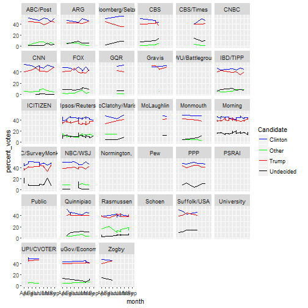

Trend from January to Present

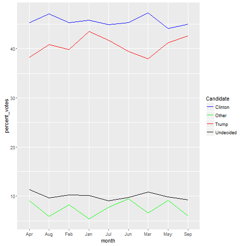

1. “Undecided” and “Other” Candidates do not seem to be in competition as indicated by all of the polls (Plot 1.).
2. Percent Votes from combined polls for each candidate based on month also indicates that the “Undecided” and “Other” Candidates are not in competition from beginning of the year. (Plot 2.)
3. Hence further reporting and predictions will be done for the top runners Hillary Clinton and Donald Trump.

Clinton Vs Trump - Polls

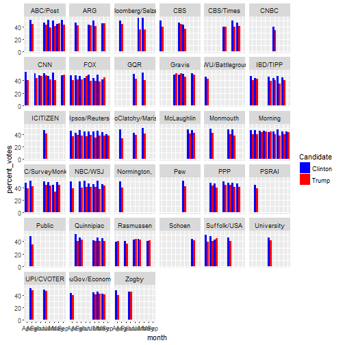

Clinton Vs Trump - Months

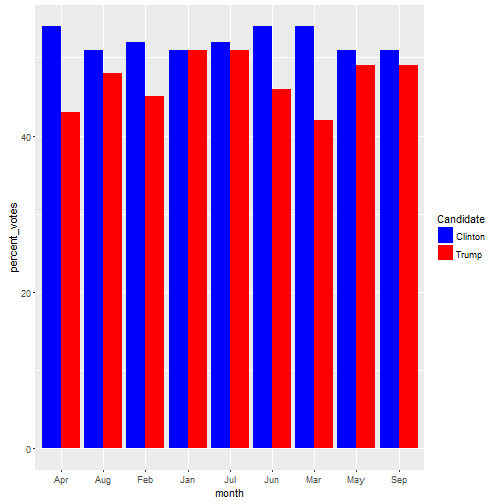

It is intersting to note that the difference in votes varies on monthly basis this could be mostly due to the issues addressed by the candidates in their rallies. Although the impact of issues on Voter's mood will not be considered in the current report, such a study in future could show intersting trends.

## Model & Predictions

Based on the observations and conclusions predicitions will be done for Hillary Clinton using TimeSeries Modelling.

Data needs to be stored in Time-Series format

```
Time Series:
Start = 1
End = 9
Frequency = 1
[1] 45.30769 47.09677 45.33333 45.77778 44.85714 45.25714 47.28000 44.06897
[9] 45.00000
```

#### Time Series Plots for Clinton monthly Trends

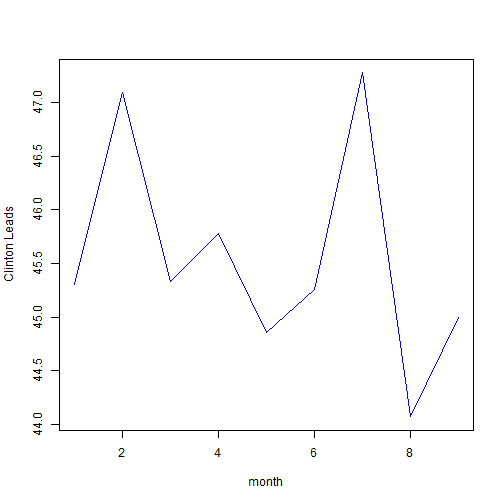

Predictions are done using forecast() function.

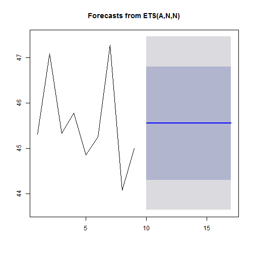

Clinton Forecast (Fitted)

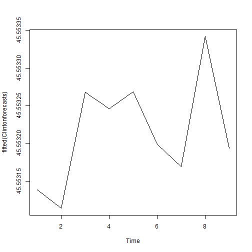

Summary of Model

```
Forecast method: ETS(A,N,N)

Model Information:
ETS(A,N,N)

Call:
 ets(y = object, lambda = lambda, allow.multiplicative.trend = allow.multiplicative.trend)

  Smoothing parameters:
    alpha = 1e-04

  Initial states:
    l = 45.5531

  sigma:  0.9778

     AIC     AICc      BIC
23.37161 25.37161 23.76606

Error measures:
                        ME      RMSE      MAE         MPE     MAPE
Training set -1.227803e-05 0.9778376 0.776684 -0.04556404 1.694556
                 MASE       ACF1
Training set 0.541124 -0.3452828

Forecasts:
   Point Forecast    Lo 80    Hi 80    Lo 95    Hi 95
10       45.55314 44.29999 46.80629 43.63661 47.46966
11       45.55314 44.29999 46.80629 43.63661 47.46966
12       45.55314 44.29999 46.80629 43.63661 47.46966
13       45.55314 44.29999 46.80629 43.63661 47.46966
14       45.55314 44.29999 46.80629 43.63661 47.46966
15       45.55314 44.29999 46.80629 43.63661 47.46966
16       45.55314 44.29999 46.80629 43.63661 47.46966
17       45.55314 44.29999 46.80629 43.63661 47.46966
```

## Conclusion

This report can be further used to study the opinion polls conducted by various agencies and get the mood of general public. This could help the Presidential candidates to address the issues identified in the polls. Since this report is a live up-to-date timeline series, strategists of the respective parties could identify the changes and act immediately to reverse any adverse trends.

## Acknowledgements

I am grateful to my mentor **Joel Bangalan** for being a constant support throught out my Data Science learning Journey and Suggesting Capstone Project and Time Series modelling method.